# $\color{purple}{\text{WeRateDogs Data Wrangling Project}}$

## **Data Analysis and Visualization**

By Osama Mohamed Naguib

## Introduction

This is project is requested during Udacity data analysis course. The objective of the WeRateDogs project is to anlyze twitter data regarding rating of dogs.

### Data comes from 3 different sources and with 3 different formats:

- Programmatic Download of `image-prediciton.tsv`
- Manual Download of `twitter-archive-enhanced.csv`
- Querying Twitter API and Composing json to txt file `tweet_json.txt`

The Image Prediction data was supplied from a software based on Macihne learnig, and were required to be downloaded programatically then to be used as a validation tool thorugh the pictures of the dogs, which some didn't have and were eliminated from the master data.

On the other hand the twitter archived was supplied for manual download through Udacity servers, and it is on CSV format, and serves as the source of the tweet_id, retweet and favourite counts, which had to be filtered to get the orignal tweet count. It also served as the source for the dogs stages data, which required very interesting cleaning approaches too.

The third part was suplied as quering Twitter API through a developer Twitter account, which I gained though some long process/investigation and a lot of communications/emails till I got the approval. then I was able to querying the Twitter API to build a josn file line by line seprated by empty line, then I iterate line by line though json.dumb till forming the TXT file, which formed the third dataset for the analysis.

Tweepy, matplotlib, pandas, numpy and other packages were used in this project.

Using the learned systematic approach for data wrangling, passing through gathering, assessing, cleaning of data, then to store it in a new clean master data in csv format, where the anlysis and visualization were done effectively, and it is the main objective of this report

This report shall answer the following questions:

- What is the most common dog breed in this dataset?
- Which dog breed received higher favourites and tweet count?
- Which dog breed had the highest rating (numerator) among other dog breeds?
- Which dog breed received the highest retweet and favourites counts?
- Which dog stage received higher rating?
- Which dog stage had higher prediction confidence in image prediction data?
- What is the most common dog name in this dataset?
- Is there is a correlation between retweet count and rating_numerator?

```python
# Import needed packages
import pandas as pd
import numpy as np
import matplotlib.pyplot as plt
```

```python
# Reading dataframe
df_master = pd.read_csv('twitter_archive_master.csv')
```

### What is the most common dog breed in this dataset?

Golden retriever is ranked no. 1 with the highest count among all dogs in the dataset followed by Labrador Retriever

```python
# Assigning shorter name for the master df
df_master = twitter_archive_master
# Value counts of dog breeds
df_master.dog_breed.value_counts()
```

```
Golden Retriever      135
Labrador Retriever     89
Pembroke               88
Chihuahua              78
Pug                    54
                     ...
Ping-Pong Ball          1
Sunglasses              1
Marmot                  1
Beach Wagon             1
Bonnet                  1
Name: dog_breed, Length: 371, dtype: int64
```

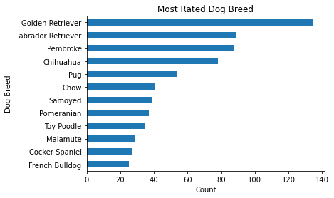

```python
df_dog_breed = df_master.groupby('dog_breed').filter(lambda x: len(x) >= 25).sort_values('dog_breed',ascending=False)

df_dog_breed['dog_breed'].value_counts().sort_values().plot(kind = 'barh')
plt.title('Most Rated Dog Breed')
plt.xlabel('Count')
plt.ylabel('Dog Breed')

fig = plt.gcf()
fig.savefig('output.png',bbox_inches='tight');
```

### Which dog breed had the highest rating (numerator) among other dog breeds?

Military Uniform has the highest rating (numerator) among other dog breeds, followed by Pole.

```python
df_master.groupby('dog_breed').mean().sort_values(by='rating_numerator', ascending=False)[:10]
```

| dog_breed | rating_numerator | rating_denominator | img_num | pred_confidence | retweet_count | favorite_count |
| --- | --- | --- | --- | --- | --- | --- |
| Military Uniform | 14.0 | 10.0 | 3.0 | 0.853684 | 3531.0 | 12292.0 |
| Pole | 14.0 | 10.0 | 2.0 | 0.478616 | 7894.0 | 30060.0 |
| Laptop | 14.0 | 10.0 | 1.0 | 0.153718 | 12972.0 | 60560.0 |
| Prison | 14.0 | 10.0 | 2.5 | 0.629938 | 12602.0 | 32019.0 |
| Pedestal | 14.0 | 10.0 | 3.0 | 0.662660 | 3291.0 | 9196.0 |
| Limousine | 14.0 | 10.0 | 1.0 | 0.130432 | 10385.0 | 42490.0 |
| Bannister | 13.0 | 10.0 | 1.0 | 0.369449 | 798.0 | 2178.0 |
| Barbell | 13.0 | 10.0 | 1.0 | 0.971581 | 9387.0 | 31725.0 |
| Upright | 13.0 | 10.0 | 1.0 | 0.303415 | 15750.0 | 30803.0 |
| Marmot | 13.0 | 10.0 | 1.0 | 0.358828 | 3777.0 | 19249.0 |

### Which dog breed received the highest retweet and favourites counts?

- Arabian Camel and Conch have the highest retweet counts.
- Conch hits again and gain the 2nd rank in favourites count.

```python
df_master.groupby('dog_breed').mean().sort_values(by='retweet_count', ascending=False)
```

| dog_breed | rating_numerator | rating_denominator | img_num | pred_confidence | retweet_count | favorite_count |
| --- | --- | --- | --- | --- | --- | --- |
| Arabian Camel | 10.0 | 10.0 | 1.5 | 0.682931 | 17335.0 | 37482.5 |
| Conch | 12.0 | 10.0 | 3.0 | 0.925621 | 17227.0 | 43144.0 |
| Upright | 13.0 | 10.0 | 1.0 | 0.303415 | 15750.0 | 30803.0 |
| Bubble | 10.0 | 10.0 | 1.0 | 0.618865 | 14821.0 | 37218.5 |
| Gondola | 9.0 | 10.0 | 1.0 | 0.226571 | 14284.0 | 24604.5 |
| ... | ... | ... | ... | ... | ... | ... |
| Piggy Bank | 9.0 | 10.0 | 1.0 | 0.176320 | 75.0 | 303.0 |
| Pitcher | 5.0 | 10.0 | 1.0 | 0.117446 | 74.0 | 337.0 |
| Platypus | 9.0 | 10.0 | 1.0 | 0.974075 | 60.0 | 309.0 |
| Crash Helmet | 10.0 | 10.0 | 1.0 | 0.757942 | 37.0 | 185.0 |
| Desktop Computer | 10.0 | 10.0 | 1.0 | 0.086502 | 32.0 | 94.0 |

371 rows × 6 columns

```python
df_master.groupby('dog_breed').mean().sort_values(by='favorite_count', ascending=False)
```

| dog_breed | rating_numerator | rating_denominator | img_num | pred_confidence | retweet_count | favorite_count |
| --- | --- | --- | --- | --- | --- | --- |
| Laptop | 14.0 | 10.0 | 1.0 | 0.153718 | 12972.0 | 60560.0 |
| Conch | 12.0 | 10.0 | 3.0 | 0.925621 | 17227.0 | 43144.0 |
| Limousine | 14.0 | 10.0 | 1.0 | 0.130432 | 10385.0 | 42490.0 |
| Angora | 7.0 | 10.0 | 1.0 | 0.571526 | 13998.5 | 42446.0 |
| Fountain | 13.0 | 10.0 | 1.0 | 0.997509 | 8036.0 | 40779.0 |
| ... | ... | ... | ... | ... | ... | ... |
| Piggy Bank | 9.0 | 10.0 | 1.0 | 0.176320 | 75.0 | 303.0 |
| Trombone | 10.0 | 10.0 | 1.0 | 0.390339 | 93.0 | 273.0 |
| Hay | 10.0 | 10.0 | 1.0 | 0.507637 | 81.0 | 224.0 |
| Crash Helmet | 10.0 | 10.0 | 1.0 | 0.757942 | 37.0 | 185.0 |
| Desktop Computer | 10.0 | 10.0 | 1.0 | 0.086502 | 32.0 | 94.0 |

371 rows × 6 columns

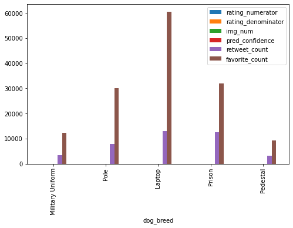

```python
df_master.groupby('dog_breed').mean().sort_values(by='rating_numerator', ascending=False)[:5].plot(kind = 'bar', figsize=(8,5));
```

```python
df_master.name.value_counts().sort_values(ascending=False)[:15]
```

```
Cooper     10
Charlie    10
Oliver     10
Lucy        9
Penny       9
Tucker      9
Sadie       8
Winston     8
Daisy       7
Lola        7
Bo          6
Koda        6
Toby        6
Bella       6
Jax         6
Name: name, dtype: int64
```

### Which dog stage had higher prediction confidence in image prediction data?

Puppo has the highest mean prediction confidence in image prediction data after the congramulate category of mixed dog stages "Multiple".

```python
df_master.groupby('dog_stage').mean()
```

| dog_stage | rating_numerator | rating_denominator | img_num | pred_confidence | retweet_count | favorite_count |
| --- | --- | --- | --- | --- | --- | --- |
| doggo | 11.870968 | 10.0 | 1.290323 | 0.574147 | 6321.758065 | 18415.290323 |
| floofer | 12.000000 | 10.0 | 1.142857 | 0.609204 | 4203.857143 | 11749.000000 |
| multiple | 11.200000 | 10.0 | 1.100000 | 0.728075 | 5135.300000 | 16541.800000 |
| pupper | 10.635000 | 10.0 | 1.255000 | 0.604128 | 2042.175000 | 6547.190000 |
| puppo | 12.000000 | 10.0 | 1.454545 | 0.722293 | 5632.181818 | 20435.272727 |

Puppo Dod stage has the highest favourites count while Doggo has the highest tweet count.

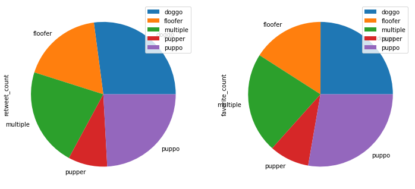

```python
df_master.iloc[:,12:].groupby('dog_stage').mean().plot(subplots= True, kind='pie', figsize=(12,8));
```

### Which dog stage received higher rating?

Floofer and Puppo had the highest rating among other dog stages.

```python
df_master.groupby('dog_stage').mean().sort_values(by='rating_numerator', ascending=False)
```

| dog_stage | rating_numerator | rating_denominator | img_num | pred_confidence | retweet_count | favorite_count |
| --- | --- | --- | --- | --- | --- | --- |
| floofer | 12.000000 | 10.0 | 1.142857 | 0.609204 | 4203.857143 | 11749.000000 |
| puppo | 12.000000 | 10.0 | 1.454545 | 0.722293 | 5632.181818 | 20435.272727 |
| doggo | 11.870968 | 10.0 | 1.290323 | 0.574147 | 6321.758065 | 18415.290323 |
| multiple | 11.200000 | 10.0 | 1.100000 | 0.728075 | 5135.300000 | 16541.800000 |
| pupper | 10.635000 | 10.0 | 1.255000 | 0.604128 | 2042.175000 | 6547.190000 |

### What is the most common dog name in this dataset?

Charlie, Oliver, and Cooper are the most common names of these dogs in this dataset.

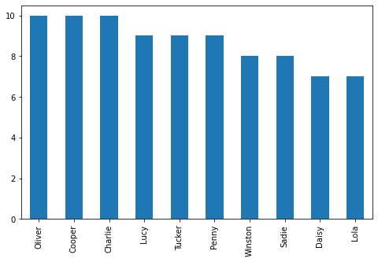

```python
df_master.name.value_counts().sort_values(ascending=False)[:10].plot(kind='bar', figsize=(8,5));
```

### Is there is a correlation between retweet count and rating_numerator?

There is a positive correlation between retweet count and rating numerator

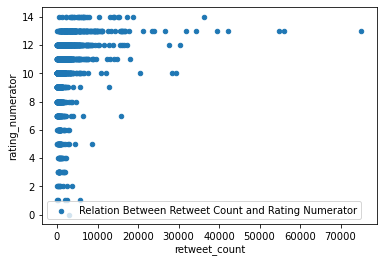

```python
df_master.plot(label='Relation Between Retweet Count and Rating Numerator', x='retweet_count', y='rating_numerator', kind='scatter');
```